# Project 2 Modeling, Testing, and Predicting

#### 2. Perform some kind of randomization test on your data (that makes sense). The statistic can be anything you want (mean difference, correlation, F-statistic/ANOVA, chi-squared), etc. State null and alternative hypotheses, perform the test, and interpret the results (7). Create a plot visualizing the null distribution and the test statistic (3).

```r
library(tidyverse)
library(vegan)
dist <- DVs %>% dist()
adonis(dist ~ treat, data = CrohnD)
```

```
##
## Call:
## adonis(formula = dist ~ treat, data = CrohnD)
##
## Permutation: free
## Number of permutations: 999
##
## Terms added sequentially (first to last)
##
##            Df SumsOfSqs MeanSqs F.Model      R2 Pr(>F)
## treat       2      1111  555.49  1.3105 0.02247  0.256
## Residuals 114     48323  423.89         0.97753
## Total     116     49434                 1.00000
```

```r
SSW <- CrohnD %>% group_by(treat) %>% select(nrAdvE, BMI, height,
    weight) %>% do(d = dist(.[2:3], "euclidean")) %>% ungroup() %>%
    summarize(sum(d[[1]]^2)/50 + sum(d[[2]]^2)/50 + sum(d[[3]]^2)/50) %>%
    pull
SST <- sum(dist^2)/117
obs_F <- ((SST - SSW)/2)/(SSW/114)

Fvals <- replicate(1000, {
    new <- CrohnD %>% mutate(treat = sample(treat))
    SSW <- new %>% group_by(treat) %>% select(nrAdvE, BMI, height,
        weight) %>% do(d = dist(.[2:3], "euclidean")) %>% ungroup() %>%
        summarize(sum(d[[1]]^2)/50 + sum(d[[2]]^2)/50 + sum(d[[3]]^2)/50) %>%
        pull
    ((SST - SSW)/2)/(SSW/114)
})

mean(Fvals > obs_F)
```

```
## [1] 0.441
```

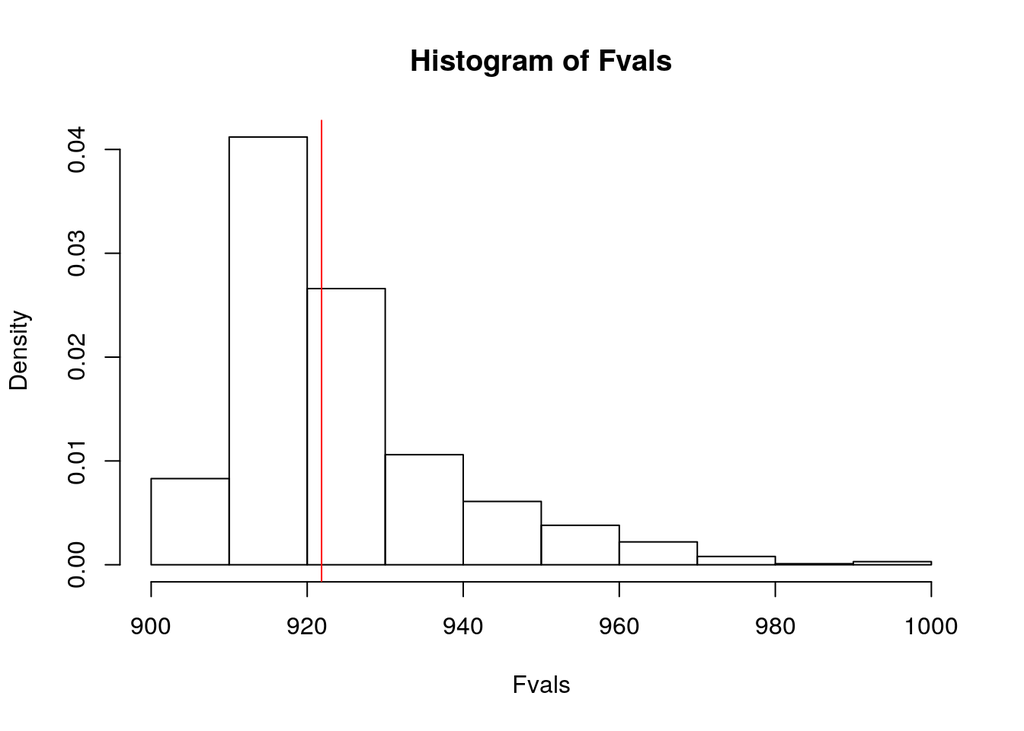

```r
hist(Fvals, prob = T)
abline(v = obs_F, col = "red", add = T)
```

*My null hypothesis is that the center and spread of the three treatment groups are the same. My alternate hypothesis is that at lest one of the cenetrs and/or spread of one treatment group is different from the other two groups. Because the p-value is greater than 0.05, we fail to reject the null hypothesis and that means that there is no significant difference of centers and spreads between the three treatment groups.*

#### 3. Build a linear regression model predicting one of your response variables from at least 2 other variables, including their interaction. Mean-center any numeric variables involved in the interaction.

```
- Interpret the coefficient estimates (do not discuss significance) (10)
- Plot the regression using `ggplot()` using geom_smooth(method="lm"). If your interaction is numeric by numeric, refer to code in the slides to make the plot or check out the `interactions` package, which makes this easier. If you have 3 or more predictors, just chose two of them to plot for conven…
- What proportion of the variation in the outcome does your model explain? (4)
- Check assumptions of linearity, normality, and homoskedasticity either graphically or using a hypothesis test (5)
- Regardless, recompute regression results with robust standard errors via `coeftest(..., vcov=vcovHC(...))`. Discuss significance of results, including any changes from before/after robust SEs if applicable. (10)
```

```r
CrohnD$nrAdvEc <- CrohnD$nrAdvE - mean(CrohnD$nrAdvE)
CrohnD$heightc <- CrohnD$height - mean(CrohnD$height)
CrohnD$weightc <- CrohnD$weight - mean(CrohnD$weight)
CrohnD$BMIc <- CrohnD$BMI - mean(CrohnD$BMI)

CrohnD <- CrohnD %>% mutate(treat = as.factor(treat))
fit <- lm(nrAdvE ~ treat * weightc, data = CrohnD)
summary(fit)
```

```
##
## Call:
## lm(formula = nrAdvE ~ treat * weightc, data = CrohnD)
##
## Residuals:
##     Min      1Q  Median      3Q     Max
## -3.4728 -1.7517 -1.1827  0.7796  9.9646
##
## Coefficients:
##                 Estimate Std. Error t value Pr(>|t|)
## (Intercept)      2.43378    0.44048   5.525  2.2e-07 ***
## treatd1         -0.82383    0.62636  -1.315    0.191
## treatd2         -0.23671    0.62753  -0.377    0.707
## weightc          0.03058    0.03844   0.796    0.428
## treatd1:weightc -0.01026    0.04991  -0.206    0.837
## treatd2:weightc -0.05334    0.04691  -1.137    0.258
## ---
## Signif. codes:  0 '***' 0.001 '**' 0.01 '*' 0.05 '.' 0.1 ' ' 1
##
## Residual standard error: 2.745 on 111 degrees of freedom
## Multiple R-squared:  0.03208,    Adjusted R-squared:  -0.01152
## F-statistic: 0.7359 on 5 and 111 DF,  p-value: 0.5981
```

```r
coef(fit)
```

```
##     (Intercept)         treatd1         treatd2         weightc treatd1:weightc
##      2.43378218     -0.82382958     -0.23671099      0.03058350     -0.01026360
## treatd2:weightc
##     -0.05334432
```

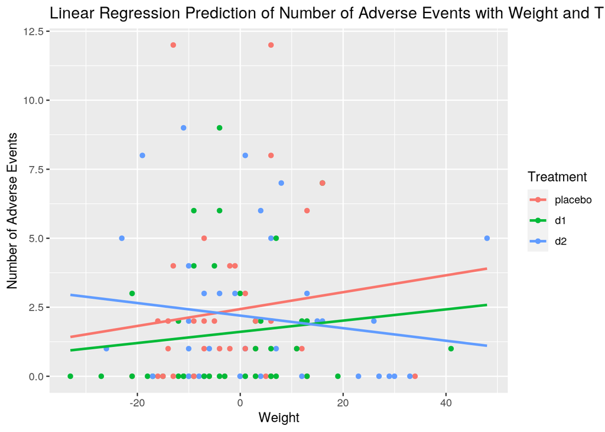

```r
CrohnD %>% ggplot(aes(weightc, nrAdvE, color = treat)) + geom_point() +
    geom_smooth(method = "lm", se = F, fullrange = T) + ggtitle("Linear Regression Prediction of Number of Adverse Events with Weight and Treatment") +
    ylab("Number of Adverse Events") + xlab("Weight") + labs(color = "Treatment")
```

```r
residual <- lm(nrAdvE ~ treat * weightc, data = CrohnD)$residuals
shapiro.test(residual)
```

```
##
##  Shapiro-Wilk normality test
##
## data:  residual
## W = 0.82849, p-value = 2.409e-10
```

```r
library(lmtest)
bptest(fit)
```

```
##
##  studentized Breusch-Pagan test
##
## data:  fit
## BP = 2.7366, df = 5, p-value = 0.7405
```

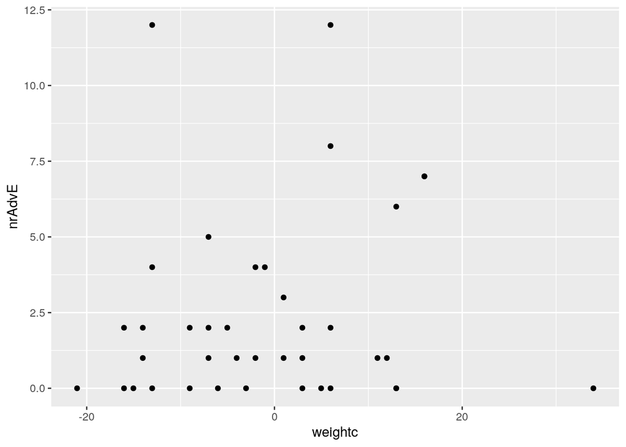

```r
CrohnD %>% filter(treat == "placebo") %>% ggplot(aes(weightc,
    nrAdvE)) + geom_point()
```